# R Notebook

Question 1: Load in the libraries you need, and look at the backpack data. Take note of variable names and dimensions

```r
library(ggplot2)
library(tidyverse)
```

```r
backpack <- CodeClanData::backpack

glimpse(backpack)
names(backpack)
```

[output not shown]

Question 2: What is the distribution of backpack weights that students are carrying?

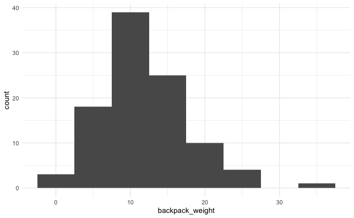

```r
ggplot(backpack) +
  aes(x = backpack_weight) +
   geom_histogram(binwidth = 5) +
  theme_minimal()
```

Question 3: Are there differences in backpack weight between sex?

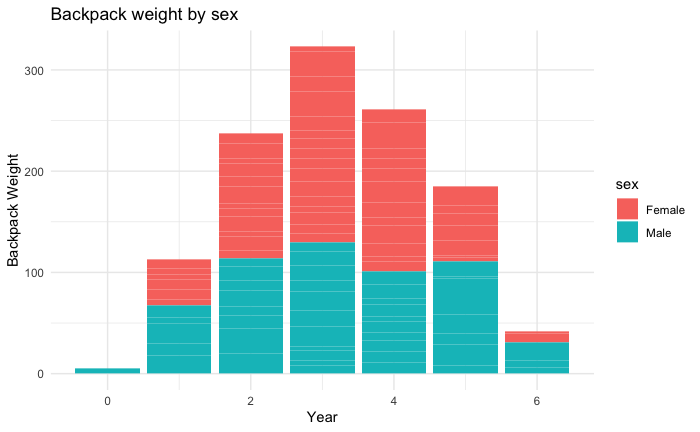

```r
ggplot(backpack, aes(x = year, y = backpack_weight, fill = sex)) +
  geom_col() +
  labs(title = "Backpack weight by sex",
       x = "Year",
       y = "Backpack Weight") +
  theme_minimal()
```

Question 4: What is the relationship between body weight and backpack weight?

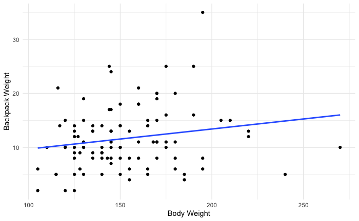

```r
ggplot(backpack, aes(x = body_weight, y = backpack_weight)) +
  geom_point() +
  geom_smooth(method = "lm", se = FALSE) +
  labs(x = "Body Weight",
       y = "Backpack Weight") +
  theme_minimal()
```

From this graph we can see that someone with a greater bodyweight is more likely to have a heavier bag. However there are a few outliers

Question 5: Is this relationship different between men and women? Choose an appropriate plot and interpret your findings.

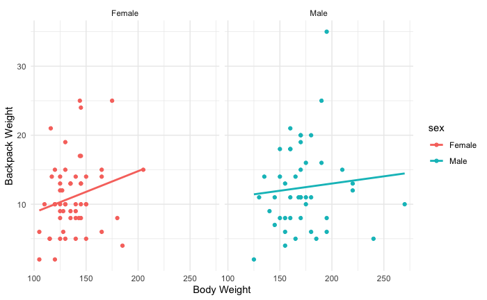

```r
ggplot(backpack, aes(x = body_weight, y = backpack_weight, colour = sex)) +
  geom_point() +
  geom_smooth(method = "lm", se = FALSE) +
  labs(x = "Body Weight",
       y = "Backpack Weight") +
  facet_wrap(~sex) +
  theme_minimal()
```

Here we can see that the trend line is greater for womnen so they are more likely to have a heavier bag with increased bodyweight when compared to men. However both trendlines suggest that backpack wight will increase with bodyweight.

Question 6:

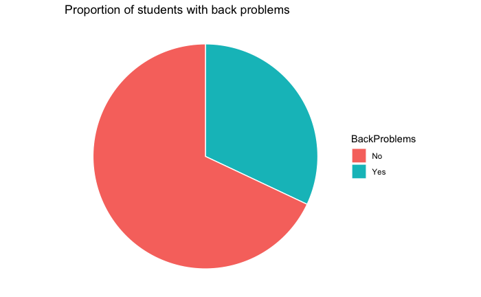

```r
prop_back_problems <- mean(backpack$back_problems)


ggplot(data.frame(BackProblems = c("Yes", "No"), Proportion = c(prop_back_problems, 1 - prop_back_problems)),
       aes(x = "", y = Proportion, fill = BackProblems)) +
  geom_bar(stat = "identity", width = 1, color = "white") +
  coord_polar("y", start = 0) +
  theme_void() +
  ggtitle("Proportion of students with back problems")
```

From this graph we can see the majority off the students do not have back problems

Question 7: Is this proportion different between men and women?

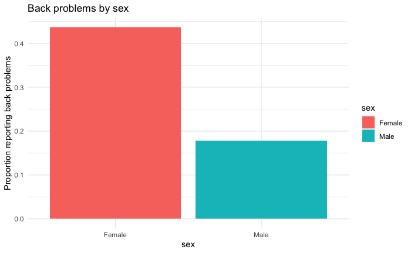

```r
prop_back_problems <- backpack %>%
  group_by(sex) %>%
  summarize(prop_back_problems = mean(back_problems))


ggplot(prop_back_problems, aes(x = sex, y = prop_back_problems, fill = sex)) +
  geom_col() +
  ylab("Proportion reporting back problems") +
  ggtitle("Back problems by sex") +
  theme_minimal()
```

Here we can see that backprolems are more common with female students

Question 8:Now you’ve investigated your data separately, create plots to describe the relationship between backpack weight, body weight, gender and reported backpain.

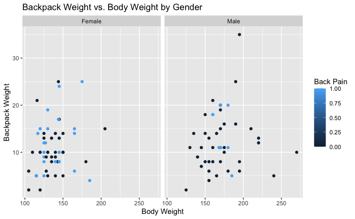

```r
ggplot(backpack, aes(x = body_weight, y = backpack_weight, color = back_problems)) +
  geom_point() +
  facet_wrap(~ sex) +
  labs(x = "Body Weight", y = "Backpack Weight", color = "Back Pain") +
  ggtitle("Backpack Weight vs. Body Weight by Gender")
```

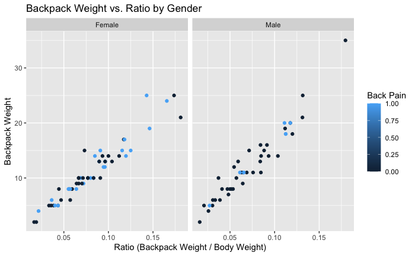

```r
ggplot(backpack, aes(x = ratio, y = backpack_weight, color = back_problems)) +
  geom_point() +
  facet_wrap(~ sex) +
  labs(x = "Ratio (Backpack Weight / Body Weight)", y = "Backpack Weight", color = "Back Pain") +
  ggtitle("Backpack Weight vs. Ratio by Gender")
```